# Домашнее задание №1

В этом домашнем задании вам предлагается обучить модель регрессии для предсказания стоимости автомобилей, а также реализовать веб-сервис для применения построенной модели на новых данных.

> Оценка за домашку = min(ваш балл, 10)

Задания, выделенные фиолетовым, требуют от вас написания кода.

А вопросы, выделенные оранжевым, текстового ответа.

Оцениваются как код, так и ответы на вопросы. Если нет одного и/или другого, то часть баллов за соответствующее задание без колебаний снимается.

```python
import warnings
warnings.filterwarnings("ignore")
```

```python
import pandas as pd
import numpy as np
import matplotlib.pyplot as plt
import random
import seaborn as sns

random.seed(42)
np.random.seed(42)
```

Ниже ответьте на вопрос "Для чего фиксируем сиды в домашках?"

Все дело в том, что в Питоне, как и в любом другом языке, используется т.н. генератор псевдо случайных чисел. Т.е. random выдает не случайное число, а число которое вычисляется алгоритмом на осное другого числа, по умолчанию это текущее время. "random.seed" позволяет изменить число, которое передается в random для генерации случайного числа, а т.к. "случайные" числа выдаются одним и тем же алгоритмом, то при одинаковом параметре в random.seed будут и одинаковые "случайные" числа. Думаю это сделано для того, чтобы получить по результатам выполнения ДЗ определенный результат.

# Часть 1 (2.5 балла + 0.75) | EDA

## Простейший EDA и обработка признаков (1.5 балла + 0.25)

```python
df_train = pd.read_csv('https://raw.githubusercontent.com/Murcha1990/MLDS_ML_2022/main/Hometasks/HT1/cars_train.csv')
df_test = pd.read_csv('https://raw.githubusercontent.com/Murcha1990/MLDS_ML_2022/main/Hometasks/HT1/cars_test.csv')

print("Train data shape:", df_train.shape)
print("Test data shape: ", df_test.shape)
```

```
Train data shape: (6999, 13)
Test data shape:  (1000, 13)
```

В результате анализа кода я нашел одну 4217 строку где max_power без числового значения, поэтом заменил данное значение на np.nan

```python
df_train.loc[df_train['max_power'] == ' bhp']
```

|  | name | year | selling_price | km_driven | fuel | seller_type | transmission | owner | mileage | engine | max_power | torque | seats |
| --- | --- | --- | --- | --- | --- | --- | --- | --- | --- | --- | --- | --- | --- |
| 4217 | Maruti Omni CNG | 2000 | 80000 | 100000 | CNG | Individual | Manual | Second Owner | 10.9 km/kg | 796 CC | bhp | NaN | 8.0 |

```python
df_train['max_power'][4217] = np.nan
```

```python
df_train.loc[[4217]]
```

|  | name | year | selling_price | km_driven | fuel | seller_type | transmission | owner | mileage | engine | max_power | torque | seats |
| --- | --- | --- | --- | --- | --- | --- | --- | --- | --- | --- | --- | --- | --- |
| 4217 | Maruti Omni CNG | 2000 | 80000 | 100000 | CNG | Individual | Manual | Second Owner | 10.9 km/kg | 796 CC | NaN | NaN | 8.0 |

(0.15 балла) Отобразите 10 **случайных** строк тренировочного датасета

```python
df_train.sample(n=10)
```

|  | name | year | selling_price | km_driven | fuel | seller_type | transmission | owner | mileage | engine | max_power | torque | seats |
| --- | --- | --- | --- | --- | --- | --- | --- | --- | --- | --- | --- | --- | --- |
| 6565 | Renault KWID Climber 1.0 MT BSIV | 2019 | 300000 | 35000 | Petrol | Individual | Manual | First Owner | 23.01 kmpl | 999 CC | 67 bhp | 91Nm@ 4250rpm | 5.0 |
| 2943 | Maruti Wagon R LXI | 2013 | 225000 | 58343 | Petrol | Trustmark Dealer | Manual | First Owner | 21.79 kmpl | 998 CC | 67.05 bhp | 90Nm@ 3500rpm | 5.0 |
| 2024 | Hyundai i20 Asta 1.2 | 2013 | 360000 | 30000 | Petrol | Individual | Manual | First Owner | 18.5 kmpl | 1197 CC | 82.85 bhp | 113.7Nm@ 4000rpm | 5.0 |
| 263 | Hyundai i20 1.2 Asta | 2010 | 300000 | 70000 | Petrol | Individual | Manual | First Owner | 17.0 kmpl | 1197 CC | 80 bhp | 11.4 kgm at 4,000 rpm | 5.0 |
| 4586 | Skoda Octavia L and K 1.9 TDI MT | 2005 | 250000 | 120000 | Diesel | Individual | Manual | Third Owner | 16.4 kmpl | 1896 CC | 90 bhp | 21.4@ 1,900(kgm@ rpm) | 5.0 |
| 4479 | Maruti Ciaz ZXi | 2016 | 700000 | 20000 | Petrol | Individual | Manual | First Owner | 20.73 kmpl | 1373 CC | 91.1 bhp | 130Nm@ 4000rpm | 5.0 |
| 4881 | Hyundai Grand i10 1.2 Kappa Magna BSIV | 2017 | 445000 | 27000 | Petrol | Individual | Manual | First Owner | 18.9 kmpl | 1197 CC | 81.86 bhp | 113.75nm@ 4000rpm | 5.0 |
| 3583 | Ford Ecosport 1.5 DV5 MT Trend | 2016 | 515000 | 68609 | Diesel | Dealer | Manual | First Owner | 22.7 kmpl | 1498 CC | 89.84 bhp | 204Nm@ 2000-2750rpm | 5.0 |
| 6361 | Hyundai Verna 1.4 VTVT | 2014 | 500000 | 33400 | Petrol | Individual | Manual | First Owner | 17.43 kmpl | 1396 CC | 105.5 bhp | 135.3Nm@ 5000rpm | 5.0 |
| 4108 | Hyundai i20 Era 1.2 | 2015 | 490000 | 45900 | Petrol | Individual | Manual | Second Owner | 18.6 kmpl | 1197 CC | 81.83 bhp | 114.7Nm@ 4000rpm | 5.0 |

(0.1 балла) Отобразите первые 5 и последние 5 объектов тестового датасета

```python
df_test.head()
```

|  | name | year | selling_price | km_driven | fuel | seller_type | transmission | owner | mileage | engine | max_power | torque | seats |
| --- | --- | --- | --- | --- | --- | --- | --- | --- | --- | --- | --- | --- | --- |
| 0 | Mahindra Xylo E4 BS IV | 2010 | 229999 | 168000 | Diesel | Individual | Manual | First Owner | 14.0 kmpl | 2498 CC | 112 bhp | 260 Nm at 1800-2200 rpm | 7.0 |
| 1 | Tata Nexon 1.5 Revotorq XE | 2017 | 665000 | 25000 | Diesel | Individual | Manual | First Owner | 21.5 kmpl | 1497 CC | 108.5 bhp | 260Nm@ 1500-2750rpm | 5.0 |
| 2 | Honda Civic 1.8 S AT | 2007 | 175000 | 218463 | Petrol | Individual | Automatic | First Owner | 12.9 kmpl | 1799 CC | 130 bhp | 172Nm@ 4300rpm | 5.0 |
| 3 | Honda City i DTEC VX | 2015 | 635000 | 173000 | Diesel | Individual | Manual | First Owner | 25.1 kmpl | 1498 CC | 98.6 bhp | 200Nm@ 1750rpm | 5.0 |
| 4 | Tata Indica Vista Aura 1.2 Safire BSIV | 2011 | 130000 | 70000 | Petrol | Individual | Manual | Second Owner | 16.5 kmpl | 1172 CC | 65 bhp | 96 Nm at 3000 rpm | 5.0 |

```python
df_test.tail()
```

|  | name | year | selling_price | km_driven | fuel | seller_type | transmission | owner | mileage | engine | max_power | torque | seats |
| --- | --- | --- | --- | --- | --- | --- | --- | --- | --- | --- | --- | --- | --- |
| 995 | Hyundai i10 Magna 1.1L | 2008 | 250000 | 100000 | Petrol | Individual | Manual | Second Owner | 19.81 kmpl | 1086 CC | 68.05 bhp | 99.04Nm@ 4500rpm | 5.0 |
| 996 | Hyundai i20 2015-2017 Sportz 1.2 | 2017 | 440000 | 50000 | Petrol | Individual | Manual | Second Owner | 18.6 kmpl | 1197 CC | 81.83 bhp | 114.7Nm@ 4000rpm | 5.0 |
| 997 | Hyundai i20 Era Diesel | 2009 | 340000 | 40000 | Diesel | Individual | Manual | First Owner | 23.0 kmpl | 1396 CC | 90 bhp | 22.4 kgm at 1750-2750rpm | 5.0 |
| 998 | Hyundai i10 Asta | 2012 | 350000 | 25000 | Petrol | Individual | Manual | First Owner | 20.36 kmpl | 1197 CC | 78.9 bhp | 111.8Nm@ 4000rpm | 5.0 |
| 999 | Honda City i DTec SV | 2016 | 700000 | 110000 | Diesel | Individual | Manual | First Owner | 26.0 kmpl | 1498 CC | 98.6 bhp | 200Nm@ 1750rpm | 5.0 |

(0.1 балла) Посчитайте основные статистики как по числовым, так и по категориальным столбцам для трейна и теста.

> Подсказка: `.describe()` с нужным(и) аргументом(-ами)

```python
df_train.describe(include='all')
```

|  | name | year | selling_price | km_driven | fuel | seller_type | transmission | owner | mileage | engine | max_power | torque | seats |
| --- | --- | --- | --- | --- | --- | --- | --- | --- | --- | --- | --- | --- | --- |
| count | 6999 | 6999.000000 | 6.999000e+03 | 6.999000e+03 | 6999 | 6999 | 6999 | 6999 | 6797 | 6797 | 6802 | 6796 | 6797.000000 |
| unique | 1924 | NaN | NaN | NaN | 4 | 3 | 2 | 5 | 386 | 120 | 315 | 419 | NaN |
| top | Maruti Swift Dzire VDI | NaN | NaN | NaN | Diesel | Individual | Manual | First Owner | 18.9 kmpl | 1248 CC | 74 bhp | 190Nm@ 2000rpm | NaN |
| freq | 116 | NaN | NaN | NaN | 3793 | 5826 | 6095 | 4587 | 197 | 885 | 330 | 468 | NaN |
| mean | NaN | 2013.818403 | 6.395152e+05 | 6.958462e+04 | NaN | NaN | NaN | NaN | NaN | NaN | NaN | NaN | 5.419008 |
| std | NaN | 4.053095 | 8.089419e+05 | 5.772400e+04 | NaN | NaN | NaN | NaN | NaN | NaN | NaN | NaN | 0.965767 |
| min | NaN | 1983.000000 | 2.999900e+04 | 1.000000e+00 | NaN | NaN | NaN | NaN | NaN | NaN | NaN | NaN | 2.000000 |
| 25% | NaN | 2011.000000 | 2.549990e+05 | 3.500000e+04 | NaN | NaN | NaN | NaN | NaN | NaN | NaN | NaN | 5.000000 |
| 50% | NaN | 2015.000000 | 4.500000e+05 | 6.000000e+04 | NaN | NaN | NaN | NaN | NaN | NaN | NaN | NaN | 5.000000 |
| 75% | NaN | 2017.000000 | 6.750000e+05 | 9.700000e+04 | NaN | NaN | NaN | NaN | NaN | NaN | NaN | NaN | 5.000000 |
| max | NaN | 2020.000000 | 1.000000e+07 | 2.360457e+06 | NaN | NaN | NaN | NaN | NaN | NaN | NaN | NaN | 14.000000 |

```python
df_test.describe(include='all')
```

|  | name | year | selling_price | km_driven | fuel | seller_type | transmission | owner | mileage | engine | max_power | torque | seats |
| --- | --- | --- | --- | --- | --- | --- | --- | --- | --- | --- | --- | --- | --- |
| count | 1000 | 1000.000000 | 1.000000e+03 | 1000.000000 | 1000 | 1000 | 1000 | 1000 | 981 | 981 | 981 | 981 | 981.000000 |
| unique | 621 | NaN | NaN | NaN | 4 | 3 | 2 | 5 | 237 | 88 | 182 | 226 | NaN |
| top | Maruti Alto 800 LXI | NaN | NaN | NaN | Diesel | Individual | Manual | First Owner | 18.6 kmpl | 1248 CC | 74 bhp | 200Nm@ 1750rpm | NaN |
| freq | 15 | NaN | NaN | NaN | 534 | 837 | 877 | 623 | 23 | 116 | 43 | 57 | NaN |
| mean | NaN | 2013.681000 | 6.179010e+05 | 71393.341000 | NaN | NaN | NaN | NaN | NaN | NaN | NaN | NaN | 5.410805 |
| std | NaN | 4.012149 | 7.585539e+05 | 48486.218662 | NaN | NaN | NaN | NaN | NaN | NaN | NaN | NaN | 0.919985 |
| min | NaN | 1995.000000 | 3.100000e+04 | 1303.000000 | NaN | NaN | NaN | NaN | NaN | NaN | NaN | NaN | 4.000000 |
| 25% | NaN | 2011.000000 | 2.500000e+05 | 37000.000000 | NaN | NaN | NaN | NaN | NaN | NaN | NaN | NaN | 5.000000 |
| 50% | NaN | 2014.000000 | 4.349990e+05 | 61500.000000 | NaN | NaN | NaN | NaN | NaN | NaN | NaN | NaN | 5.000000 |
| 75% | NaN | 2017.000000 | 6.700000e+05 | 100000.000000 | NaN | NaN | NaN | NaN | NaN | NaN | NaN | NaN | 5.000000 |
| max | NaN | 2020.000000 | 6.000000e+06 | 375000.000000 | NaN | NaN | NaN | NaN | NaN | NaN | NaN | NaN | 9.000000 |

(0.15 балла) Посмотрите, есть ли в датасете пропуски.

Если есть, то в каких колонках?

```python
df_train.isna().sum()
```

```
name               0
year               0
selling_price      0
km_driven          0
fuel               0
seller_type        0
transmission       0
owner              0
mileage          202
engine           202
max_power        197
torque           203
seats            202
dtype: int64
```

В тренировочной датасете присутствуют пропуски в столбцах: mileage, engine, max_power, torque, seats. Количество пропусков отражены выше в таблице.

```python
df_test.isna().sum()
```

```
name              0
year              0
selling_price     0
km_driven         0
fuel              0
seller_type       0
transmission      0
owner             0
mileage          19
engine           19
max_power        19
torque           19
seats            19
dtype: int64
```

В тестовом датасете присутствуют пропуски в столбцах: mileage, engine, max_power, torque, seats. Количество пропусков отражены выше в таблице.

(0.1 балла) Посмотрите, есть ли в трейне объекты с одинаковым признаковым описанием (целевую переменную следует исключить). Если есть, то сколько?

```python
# Исключаем целевую переменную
df_train_wc = df_train.drop(labels=['selling_price'],axis=1,inplace=False)

# Ищем количество дубликатов
df_train_wc.duplicated().sum()
```

```
1159
```

Обнаружено 1159 строк, которые дублируют уже имеющиеся строки в ДатаФрейме.

(0.15 балла) Отобразите такие объекты

```python
df_train_wc[df_train_wc.duplicated()]
```

|  | name | year | km_driven | fuel | seller_type | transmission | owner | mileage | engine | max_power | torque | seats |
| --- | --- | --- | --- | --- | --- | --- | --- | --- | --- | --- | --- | --- |
| 254 | Hyundai Grand i10 Sportz | 2017 | 35000 | Petrol | Individual | Manual | First Owner | 18.9 kmpl | 1197 CC | 82 bhp | 114Nm@ 4000rpm | 5.0 |
| 258 | Maruti Swift VXI | 2012 | 50000 | Petrol | Individual | Manual | Second Owner | 18.6 kmpl | 1197 CC | 85.8 bhp | 114Nm@ 4000rpm | 5.0 |
| 268 | Maruti Swift Dzire VXI | 2014 | 70000 | Petrol | Individual | Manual | Second Owner | 19.1 kmpl | 1197 CC | 85.8 bhp | 114Nm@ 4000rpm | 5.0 |
| 324 | Jaguar XE 2016-2019 2.0L Diesel Prestige | 2017 | 9000 | Diesel | Dealer | Automatic | First Owner | 13.6 kmpl | 1999 CC | 177 bhp | 430Nm@ 1750-2500rpm | 5.0 |
| 325 | Lexus ES 300h | 2019 | 20000 | Petrol | Dealer | Automatic | First Owner | 22.37 kmpl | 2487 CC | 214.56 bhp | 202Nm@ 3600-5200rpm | 5.0 |
| ... | ... | ... | ... | ... | ... | ... | ... | ... | ... | ... | ... | ... |
| 6947 | Chevrolet Spark 1.0 LS | 2010 | 60000 | Petrol | Individual | Manual | Second Owner | 18.0 kmpl | 995 CC | 62 bhp | 90.3Nm@ 4200rpm | 5.0 |
| 6984 | Ford Freestyle Titanium Plus Diesel BSIV | 2018 | 24000 | Diesel | Individual | Manual | First Owner | 24.4 kmpl | 1498 CC | 98.63 bhp | 215Nm@ 1750-3000rpm | 5.0 |
| 6989 | Maruti Swift Dzire VDI | 2015 | 50000 | Diesel | Individual | Manual | First Owner | 26.59 kmpl | 1248 CC | 74 bhp | 190Nm@ 2000rpm | 5.0 |
| 6997 | Tata Indigo CR4 | 2013 | 25000 | Diesel | Individual | Manual | First Owner | 23.57 kmpl | 1396 CC | 70 bhp | 140Nm@ 1800-3000rpm | 5.0 |
| 6998 | Tata Indigo CR4 | 2013 | 25000 | Diesel | Individual | Manual | First Owner | 23.57 kmpl | 1396 CC | 70 bhp | 140Nm@ 1800-3000rpm | 5.0 |

1159 rows × 12 columns

(0.15 балла) Удалите повторяющиеся строки. Если при одинаковом признаковом описании цены на автомобили отличаются, то оставьте первую строку по этому автомобилю

```python
# Получим индексы тех строк, что дублируются
df_train_wc_index = list(df_train_wc[df_train_wc.duplicated()].index)

# Проверим их по количеству
len(df_train_wc_index)
```

```
1159
```

Использованный метод .duplicated() фиксирует последующиеся повторяющиеся значения строк. То есть он не отслеживает 1 строку в ДатаФрейме, у которой есть повторы. Таким образом, если мы удалим те строки с индексами, содержащимися в df_train_wc_index мы выполним условие задачи

```python
df_train_wc = df_train.drop(labels=df_train_wc_index,axis=0,inplace=False)
df_train_wc.shape
```

```
(5840, 13)
```

```python
df_train = df_train_wc
```

```python
assert df_train.shape == (5840, 13)
```

(0.1 балла) Чтоб все было по красоте, обновите индексы строк таким образом, чтобы они шли от 0 без пропусков

```python
df_train.reset_index(drop=True,inplace=True)
df_train
```

|  | name | year | selling_price | km_driven | fuel | seller_type | transmission | owner | mileage | engine | max_power | torque | seats |
| --- | --- | --- | --- | --- | --- | --- | --- | --- | --- | --- | --- | --- | --- |
| 0 | Maruti Swift Dzire VDI | 2014 | 450000 | 145500 | Diesel | Individual | Manual | First Owner | 23.4 kmpl | 1248 CC | 74 bhp | 190Nm@ 2000rpm | 5.0 |
| 1 | Skoda Rapid 1.5 TDI Ambition | 2014 | 370000 | 120000 | Diesel | Individual | Manual | Second Owner | 21.14 kmpl | 1498 CC | 103.52 bhp | 250Nm@ 1500-2500rpm | 5.0 |
| 2 | Hyundai i20 Sportz Diesel | 2010 | 225000 | 127000 | Diesel | Individual | Manual | First Owner | 23.0 kmpl | 1396 CC | 90 bhp | 22.4 kgm at 1750-2750rpm | 5.0 |
| 3 | Maruti Swift VXI BSIII | 2007 | 130000 | 120000 | Petrol | Individual | Manual | First Owner | 16.1 kmpl | 1298 CC | 88.2 bhp | 11.5@ 4,500(kgm@ rpm) | 5.0 |
| 4 | Hyundai Xcent 1.2 VTVT E Plus | 2017 | 440000 | 45000 | Petrol | Individual | Manual | First Owner | 20.14 kmpl | 1197 CC | 81.86 bhp | 113.75nm@ 4000rpm | 5.0 |
| ... | ... | ... | ... | ... | ... | ... | ... | ... | ... | ... | ... | ... | ... |
| 5835 | Hyundai Santro Xing GLS | 2008 | 120000 | 191000 | Petrol | Individual | Manual | First Owner | 17.92 kmpl | 1086 CC | 62.1 bhp | 96.1Nm@ 3000rpm | 5.0 |
| 5836 | Maruti Wagon R VXI BS IV with ABS | 2013 | 260000 | 50000 | Petrol | Individual | Manual | Second Owner | 18.9 kmpl | 998 CC | 67.1 bhp | 90Nm@ 3500rpm | 5.0 |
| 5837 | Hyundai i20 Magna | 2013 | 320000 | 110000 | Petrol | Individual | Manual | First Owner | 18.5 kmpl | 1197 CC | 82.85 bhp | 113.7Nm@ 4000rpm | 5.0 |
| 5838 | Hyundai Verna CRDi SX | 2007 | 135000 | 119000 | Diesel | Individual | Manual | Fourth & Above Owner | 16.8 kmpl | 1493 CC | 110 bhp | 24@ 1,900-2,750(kgm@ rpm) | 5.0 |
| 5839 | Maruti Swift Dzire ZDi | 2009 | 382000 | 120000 | Diesel | Individual | Manual | First Owner | 19.3 kmpl | 1248 CC | 73.9 bhp | 190Nm@ 2000rpm | 5.0 |

5840 rows × 13 columns

Вы могли заметить, что с признаками `mileage, engine, max_power и torque` всё не слава богу. Давайте починим.

(0.25 балла) Задача такая:

- убрать единицы измерения для признаков `mileage, engine, max_power`.
- кастануть эти столбцы столбцы к `float`.
- удалить столбец `torque` </font>

> Все действия нужно производить над обоими датасетами

**Доп (0.25 балла):**

- Вместо удаления признак `torque` разделите на два: собственно `torque` и `max_torque_rpm`. Учтите единицы измерения. Они разные ☹

Уберем единицы измерения для признаков mileage, engine, max_power и преобразования их значений ко float

```python
# Для того, чтобы убрать единицы измерения удобно будет воспользоваться регулярными выражениями
import re
from tqdm import tqdm
```

```python
# Функция change для удаления единиц измерения в определенном столбце name и преобразований ко float

def change(df_feat, name):
    for i in tqdm(range(len(df_feat))):
        try:
            df_feat[name][i] = re.findall(r'\d+[\.\d+|\d+]', str(df_feat[name][i]))[0]
        except:
            df_feat[name][i] = df_feat[name][i]
    return df_feat[name].astype(float)

# Удаление единиц измерения из указанных столбцов

df_train_feat = df_train.copy()

df_train_feat['mileage'] = change(df_train_feat, 'mileage')
df_train_feat['engine'] = change(df_train_feat, 'engine')
df_train_feat['max_power'] = change(df_train_feat, 'max_power')

df_test_feat = df_test.copy()

df_test_feat['mileage'] = change(df_test_feat, 'mileage')
df_test_feat['engine'] = change(df_test_feat, 'engine')
df_test_feat['max_power'] = change(df_test_feat, 'max_power')
```

Добавим столбец max_torque_rpm и возьмем максимальное значение rpm данного автомобиля, далее в столбце torque оставим только число при единице измерения Nm или kgm, предварительно переведя его в Nm умножением на 9,8.

```python
# Найдем индексы объектов, у которых torque измеряется в kgm для перевода этих значений в Nm
df_train_feat_next = df_train_feat.copy()

# Предварительно сделаем все буквы строчными и запомним индексы объектов с единицей измерения kgm
index_kgm = []
for i in tqdm(range(len(df_train_feat_next))):
    if type(df_train_feat_next['torque'][i]) != float:
        df_train_feat_next['torque'][i] = df_train_feat_next['torque'][i].lower()
        if 'kgm' in df_train_feat_next['torque'][i]:
              index_kgm.append(i)
```

```python
# Применяем регулярные выражения для поиска нужных чисел

df_train_feat_next_1 = df_train_feat_next.copy()
df_train_feat_next_1.insert(2, 'max_torque_rpm', [np.nan for i in range(len(df_train_feat_next_1))], True)
index_another = []

for i in tqdm(range(len(df_train_feat_next_1))):

    df_train_feat_next_1['torque'][i] = re.findall(r'\d+[\.|\,|\d+]\d+', str(df_train_feat_next_1['torque'][i]))

    if df_train_feat_next_1['torque'][i] != []:

# Значения с этими индексами надо будет потом заменить по другому шаблону
        if len(df_train_feat_next_1['torque'][i]) == 1:
            index_another.append(i)

        df_train_feat_next_1['torque'][i][-1].replace(',','.')
        df_train_feat_next_1['max_torque_rpm'][i] =  float(df_train_feat_next_1['torque'][i][-1].replace(',','.'))
        df_train_feat_next_1['torque'][i] = float(df_train_feat_next_1['torque'][i][0].replace(',','.'))

        if i in index_kgm:
            df_train_feat_next_1['torque'][i] = df_train_feat_next_1['torque'][i] * 9.8
    else:
            df_train_feat_next_1['torque'][i] = np.nan
```

```python
# Вот и другой шаблон для особенных значений признаков

df_train_feat_next_end = df_train_feat_next_1.copy()
index_another_2 = []

for i in tqdm(range(len(df_train_feat_next_end))):
    if i in index_another:
        df_train_feat_next_end['torque'][i] = re.findall(r'\d+', str(df_train_feat['torque'][i]))

        if len(df_train_feat_next_end['torque'][i]) != 2:
            index_another_2.append(i)

        if df_train_feat_next_end['torque'][i] != []:
            df_train_feat_next_end['torque'][i][-1].replace(',','.')
            df_train_feat_next_end['max_torque_rpm'][i] =  float(df_train_feat_next_end['torque'][i][-1].replace(',','.'))
            df_train_feat_next_end['torque'][i] = float(df_train_feat_next_end['torque'][i][0].replace(',','.'))

            if i in index_kgm:
                df_train_feat_next_end['torque'][i] = df_train_feat_next_end['torque'][i] * 9,8
        else:
                df_train_feat_next_end['torque'][i] = np.nan
```

```python
# Остальные не типовые значения заменим на np.nan, хотя можно было бы и их разложить.
# Их очень мало осталось не обработанных значений и я пошел этим путем

for i in tqdm(range(len(df_train_feat_next_end))):
    if i in index_another_2:
        df_train_feat_next_end['torque'][i] = np.nan
```

```python
# Заменим одно еще значение np.nan. Таких значений крайне мало, поэтому я не стал вводить для них шаблоны.
# Их порядка 10 в общей сложности и они выбиваются из правил по шаблону из огромного большинства.

for i in tqdm(range(len(df_train_feat_next_end))):

    if type(df_train_feat_next_end['torque'][i]) != float:
        df_train_feat_next_end['torque'][i] = np.nan
```

```python
# Проверка типов
df_train_feat_next_end.dtypes
```

```
name               object
year                int64
max_torque_rpm    float64
selling_price       int64
km_driven           int64
fuel               object
seller_type        object
transmission       object
owner              object
mileage           float64
engine            float64
max_power         float64
torque             object
seats             float64
dtype: object
```

```python
# Тоже самое проделаем для теста один в один

# Найдем индексы объектов, у которых torque измеряется в kgm для перевода этих значений в Nm
df_test_feat_next = df_test_feat.copy()

# Предварительно сделаем все буквы строчными и запомним индексы объектов с единицей измерения kgm
index_kgm = []
for i in tqdm(range(len(df_test_feat_next))):
    if type(df_test_feat_next['torque'][i]) != float:
        df_test_feat_next['torque'][i] = df_test_feat_next['torque'][i].lower()
        if 'kgm' in df_test_feat_next['torque'][i]:
              index_kgm.append(i)

df_test_feat_next_1 = df_test_feat_next.copy()
df_test_feat_next_1.insert(2, 'max_torque_rpm', [np.nan for i in range(len(df_test_feat_next_1))], True)
index_another = []

for i in tqdm(range(len(df_test_feat_next_1))):

    df_test_feat_next_1['torque'][i] = re.findall(r'\d+[\.|\,|\d+]\d+', str(df_test_feat_next_1['torque'][i]))

    if df_test_feat_next_1['torque'][i] != []:

# Значения с этими индексами надо будет потом заменить по другому шаблону
        if len(df_test_feat_next_1['torque'][i]) == 1:
            index_another.append(i)

        df_test_feat_next_1['torque'][i][-1].replace(',','.')
        df_test_feat_next_1['max_torque_rpm'][i] =  float(df_test_feat_next_1['torque'][i][-1].replace(',','.'))
        df_test_feat_next_1['torque'][i] = float(df_test_feat_next_1['torque'][i][0].replace(',','.'))

        if i in index_kgm:
            df_test_feat_next_1['torque'][i] = df_test_feat_next_1['torque'][i] * 9.8
    else:
            df_test_feat_next_1['torque'][i] = np.nan

# Вот и другой шаблон для особенных значений признаков
df_test_feat_next_end = df_test_feat_next_1.copy()
index_another_2 = []

for i in tqdm(range(len(df_train_feat_next_end))):
    if i in index_another:
        df_test_feat_next_end['torque'][i] = re.findall(r'\d+', str(df_test_feat['torque'][i]))

        if len(df_test_feat_next_end['torque'][i]) != 2:
            index_another_2.append(i)

        if df_test_feat_next_end['torque'][i] != []:
            df_test_feat_next_end['torque'][i][-1].replace(',','.')
            df_test_feat_next_end['max_torque_rpm'][i] =  float(df_test_feat_next_end['torque'][i][-1].replace(',','.'))
            df_test_feat_next_end['torque'][i] = float(df_test_feat_next_end['torque'][i][0].replace(',','.'))

            if i in index_kgm:
                df_test_feat_next_end['torque'][i] = df_test_feat_next_end['torque'][i] * 9,8
        else:
                df_test_feat_next_end['torque'][i] = np.nan

# Остальные не типовые значения заменим на np.nan, хотя можно было бы и их разложить.
# Их очень мало осталось не обработанных
for i in tqdm(range(len(df_test_feat_next_end))):
    if i in index_another_2:
        df_test_feat_next_end['torque'][i] = np.nan

# Заменим одно еще значение np.nan. Таких значений крайне мало, поэтому я не стал вводить для них шаблоны.
# Их порядка 10 в общей сложности и они выбиваются из правил огромного большинства.

for i in tqdm(range(len(df_test_feat_next_end))):

    if type(df_test_feat_next_end['torque'][i]) != float:
        df_test_feat_next_end['torque'][i] = np.nan
```

```python
df_test_feat_next_end.dtypes
```

```
name               object
year                int64
max_torque_rpm    float64
selling_price       int64
km_driven           int64
fuel               object
seller_type        object
transmission       object
owner              object
mileage           float64
engine            float64
max_power         float64
torque             object
seats             float64
dtype: object
```

```python
# Отразим ситуацию как было до преобразования
df_train_feat.head()
```

|  | name | year | selling_price | km_driven | fuel | seller_type | transmission | owner | mileage | engine | max_power | torque | seats |
| --- | --- | --- | --- | --- | --- | --- | --- | --- | --- | --- | --- | --- | --- |
| 0 | Maruti Swift Dzire VDI | 2014 | 450000 | 145500 | Diesel | Individual | Manual | First Owner | 23.0 | 1248.0 | 74.0 | 190Nm@ 2000rpm | 5.0 |
| 1 | Skoda Rapid 1.5 TDI Ambition | 2014 | 370000 | 120000 | Diesel | Individual | Manual | Second Owner | 21.0 | 1498.0 | 103.0 | 250Nm@ 1500-2500rpm | 5.0 |
| 2 | Hyundai i20 Sportz Diesel | 2010 | 225000 | 127000 | Diesel | Individual | Manual | First Owner | 23.0 | 1396.0 | 90.0 | 22.4 kgm at 1750-2750rpm | 5.0 |
| 3 | Maruti Swift VXI BSIII | 2007 | 130000 | 120000 | Petrol | Individual | Manual | First Owner | 16.0 | 1298.0 | 88.0 | 11.5@ 4,500(kgm@ rpm) | 5.0 |
| 4 | Hyundai Xcent 1.2 VTVT E Plus | 2017 | 440000 | 45000 | Petrol | Individual | Manual | First Owner | 20.0 | 1197.0 | 81.0 | 113.75nm@ 4000rpm | 5.0 |

```python
# А теперь как стало
df_train_feat_next_end.head()
```

|  | name | year | max_torque_rpm | selling_price | km_driven | fuel | seller_type | transmission | owner | mileage | engine | max_power | torque | seats |
| --- | --- | --- | --- | --- | --- | --- | --- | --- | --- | --- | --- | --- | --- | --- |
| 0 | Maruti Swift Dzire VDI | 2014 | 2000.0 | 450000 | 145500 | Diesel | Individual | Manual | First Owner | 23.0 | 1248.0 | 74.0 | 190.0 | 5.0 |
| 1 | Skoda Rapid 1.5 TDI Ambition | 2014 | 2500.0 | 370000 | 120000 | Diesel | Individual | Manual | Second Owner | 21.0 | 1498.0 | 103.0 | 250.0 | 5.0 |
| 2 | Hyundai i20 Sportz Diesel | 2010 | 2750.0 | 225000 | 127000 | Diesel | Individual | Manual | First Owner | 23.0 | 1396.0 | 90.0 | 219.52 | 5.0 |
| 3 | Maruti Swift VXI BSIII | 2007 | 4.5 | 130000 | 120000 | Petrol | Individual | Manual | First Owner | 16.0 | 1298.0 | 88.0 | 112.7 | 5.0 |
| 4 | Hyundai Xcent 1.2 VTVT E Plus | 2017 | 4000.0 | 440000 | 45000 | Petrol | Individual | Manual | First Owner | 20.0 | 1197.0 | 81.0 | 113.75 | 5.0 |

(0.15 балла) Заполните пропуски в столбцах медианами. Убедитесь, что после заполнения пропусков не осталось

> Обратите внимание, что, по уму, нужно посчитать медиану по трейну и этим средним заполнять пропуски в тесте. Так же делаем, если, например, стандартизируем признаки.

```python
import statistics
from sklearn.impute import SimpleImputer
```

```python
df_train_feat_wnan = df_train_feat_next_end.copy()
df_train_feat_wnan.isnull().sum()
```

```
name                0
year                0
max_torque_rpm    187
selling_price       0
km_driven           0
fuel                0
seller_type         0
transmission        0
owner               0
mileage           186
engine            186
max_power         184
torque            222
seats             186
dtype: int64
```

```python
for i in tqdm(range(len(df_train_feat_wnan))):
    if type(df_train_feat_wnan['torque'][i]) != float:
        df_train_feat_wnan['torque'] =  df_train_feat_wnan['torque'].astype(float)
```

```python
# Для вещественнозначных признаков заполним пропуски медианами

X_real = df_train_feat_wnan[['mileage', 'engine', 'max_power', 'seats', 'max_torque_rpm', 'torque']]
mis_replacer = SimpleImputer(strategy="median")
X_no_mis_real = pd.DataFrame(data=mis_replacer.fit_transform(X_real), columns=X_real.columns)
```

```python
# Заменим значения столбцов в исходном датасете

df_train_feat_wnan[['mileage']] = X_no_mis_real[['mileage']]
df_train_feat_wnan[['engine']] = X_no_mis_real[['engine']]
df_train_feat_wnan[['max_power']] = X_no_mis_real[['max_power']]
df_train_feat_wnan[['seats']] = X_no_mis_real[['seats']]
df_train_feat_wnan[['max_torque_rpm']] = X_no_mis_real[['max_torque_rpm']]
df_train_feat_wnan[['torque']] = X_no_mis_real[['torque']]
```

```python
# Проверим наличие пропущенных значений
df_train_feat_wnan.isnull().sum()
```

```
name              0
year              0
max_torque_rpm    0
selling_price     0
km_driven         0
fuel              0
seller_type       0
transmission      0
owner             0
mileage           0
engine            0
max_power         0
torque            0
seats             0
dtype: int64
```

```python
median_1 = statistics.median(df_train_feat_wnan['mileage'])
median_2 = statistics.median(df_train_feat_wnan['engine'])
median_3 = statistics.median(df_train_feat_wnan['max_power'])
median_4 = statistics.median(df_train_feat_wnan['seats'])
median_5 = statistics.median(df_train_feat_wnan['max_torque_rpm'])
median_6 = statistics.median(df_train_feat_wnan['torque'])

df_test_feat_wnan = df_test_feat_next_end.copy()
```

```python
# Для вещественнозначных признаков заполним найденными ранее медианами

X_real = df_test_feat_wnan[['mileage', 'engine', 'max_power', 'seats', 'max_torque_rpm', 'torque']]
mis_replacer = SimpleImputer(fill_value = [median_1,median_2,median_3,median_4,median_5,median_6])
X_no_mis_real = pd.DataFrame(data=mis_replacer.fit_transform(X_real), columns=X_real.columns)
```

```python
# Заменим значения столбцов в исходном датасете

df_test_feat_wnan[['mileage']] = X_no_mis_real[['mileage']]
df_test_feat_wnan[['engine']] = X_no_mis_real[['engine']]
df_test_feat_wnan[['max_power']] = X_no_mis_real[['max_power']]
df_test_feat_wnan[['seats']] = X_no_mis_real[['seats']]
df_test_feat_wnan[['max_torque_rpm']] = X_no_mis_real[['max_torque_rpm']]
df_test_feat_wnan[['torque']] = X_no_mis_real[['torque']]
```

```python
# Проверим наличие пропущенных значений
df_test_feat_wnan.isnull().sum()
```

```
name              0
year              0
max_torque_rpm    0
selling_price     0
km_driven         0
fuel              0
seller_type       0
transmission      0
owner             0
mileage           0
engine            0
max_power         0
torque            0
seats             0
dtype: int64
```

Видно, что пропущенные значения в test отсутствуют.

(0.1 балла) Теперь, когда не осталось пропусков, можно преобразовать столбцы к более подходящим типам (``engnine`` и ``seats`` к int)

Ниже ответьте, почему (хоть мы этого и не делаем) ``seats``, возможно, лучше сделать переменной категориальной, а не целочисленной.

Seats тот признак, хоть и задается числом, но является категориальным признаком. Число мест лишь задает характеристику авто, которая лишь описывается числом, которое нелзя применять для дальнейшего анализа, так как это просто свойство.

```python
# Преобразование столбцов к более подходящим типам (engnine и seats к int) для train

df_train_feat_wnan_int = df_train_feat_wnan.copy()
df_train_feat_wnan_int[['mileage', 'seats']] = df_train_feat_wnan_int[['mileage', 'seats']].round(0)
df_train_feat_wnan_int[['mileage', 'seats']] = df_train_feat_wnan_int[['mileage', 'seats']].astype(int)

# Преобразование столбцов к более подходящим типам (engnine и seats к int) для test

df_test_feat_wnan_int = df_test_feat_wnan.copy()
df_test_feat_wnan_int[['mileage', 'seats']] = df_test_feat_wnan_int[['mileage', 'seats']].round(0)
df_test_feat_wnan_int[['mileage', 'seats']] = df_test_feat_wnan_int[['mileage', 'seats']].astype(int)
```

```python
# Проверка полученных типов

df_train_feat_wnan_int[['mileage', 'seats']].dtypes
```

```
mileage    int32
seats      int32
dtype: object
```

```python
df_test_feat_wnan_int[['mileage', 'seats']].dtypes
```

```
mileage    int32
seats      int32
dtype: object
```

## Визуализации (1 балл + 0.5)

Визуализировать нам надо не так уж и много. Во-первых, хотелось бы, в принципе, увидеть как распределены значения признаков. Также хотелось бы понять, насколько признаки скоррелированы между собой и с целевой переменной. А ещё неплохо бы посмотреть, не оказалось ли так, что тестовые данные распределены иначе, чем трейн.

Этим всем и предлагаем вам заняться.

(0.25 балла) Посторойте попарные распределения всех числовых признаков для трейна.

> `sns.paiplot()` позволяет сделать это в одну строчку

```python
import seaborn as sns
```

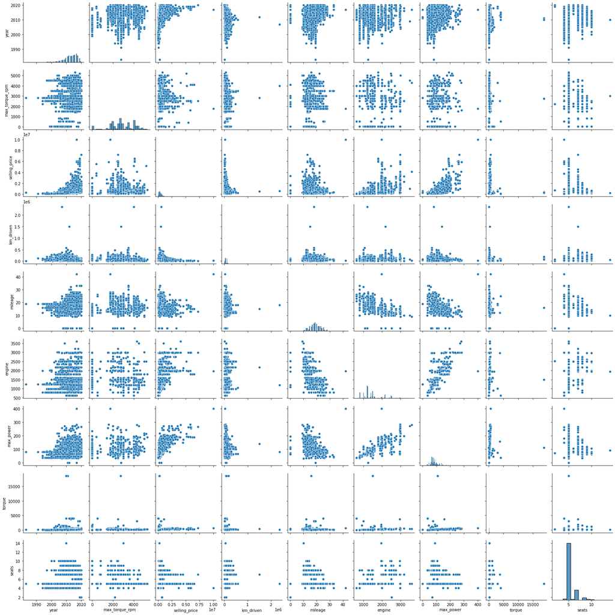

```python
sns.pairplot(df_train_feat_wnan_int)
plt.show()
```

Этот график не такой информативный, как можно было бы построить, беря признаки по отдельности. Но он позволяет сделать некоторые (возможно, далеко идущие) выводы. Впрочем, со многими из них (если не со всеми) вы бы справились умозрительно. Однако всегда приятно делать выводы, основываясь на данных.

- Что можно сказать о связи предикторов с целевой переменной?
- А о корреляциях признаков? </font>

Введем пояснения по каждому признаку:  
year - год выпуска авто;  
selling_price - цена продажи;  
km_driven - пробег;  
mileage - километры автомобиля на один литр топлива (расход);  
engine - объем двигателя;  
max_power - мощность двигателя;  
max_torque_rpm - максимальный крутящий момент;  
torque - крутящий момент;  
seats - число мест пассажиров.

Из построенных распределений можно сделать следующие выводы зависимости целевой переменной от признаков:

1. Видно что с годом выпуска (year) цена на машину (selling_price) увеличивается. Чем более новая машина, тем она дороже.
2. При увеличении пробега (km_driven) и расхода (mileage) цена на машину (selling_price) уменьшается.
3. При увеличении мощности (max_power) и объема двигателя (engine) цена на машину (selling_price) растет.
4. С увеличением количества мест (seats) цена на машину (selling_price) падает. Тут я думаю дело в том, что самый топ сегмент это 5-ти местные стандартные машины, спрос на них наивысок. Хотя, что странно, коэффициент корреляции между ними маленький, но положительный, что говорит об обратном и что я не вижу на графике.
5. Цена на машину (selling_price) практически не зависит от максимального крутящего момента (max_torque_rpm), но при увеличении крутящего момента (torque) цена (selling_price) незначительно возрастает.

```python
# Выведем коэффициенты корреляции для ответа на вопрос по корреляции признаков
df_train_feat_wnan_int.corr()
```

|  | year | max_torque_rpm | selling_price | km_driven | mileage | engine | max_power | torque | seats |
| --- | --- | --- | --- | --- | --- | --- | --- | --- | --- |
| year | 1.000000 | 0.229224 | 0.427279 | -0.368966 | 0.340980 | 0.002819 | 0.155518 | -0.012432 | 0.041178 |
| max_torque_rpm | 0.229224 | 1.000000 | 0.001802 | -0.231577 | -0.041586 | -0.215914 | -0.012949 | -0.057738 | -0.139223 |
| selling_price | 0.427279 | 0.001802 | 1.000000 | -0.164828 | -0.101870 | 0.447672 | 0.692608 | 0.041672 | 0.149953 |
| km_driven | -0.368966 | -0.231577 | -0.164828 | 1.000000 | -0.184259 | 0.229766 | 0.025558 | 0.022239 | 0.192328 |
| mileage | 0.340980 | -0.041586 | -0.101870 | -0.184259 | 1.000000 | -0.574745 | -0.366024 | -0.049050 | -0.457939 |
| engine | 0.002819 | -0.215914 | 0.447672 | 0.229766 | -0.574745 | 1.000000 | 0.682608 | 0.071754 | 0.652172 |
| max_power | 0.155518 | -0.012949 | 0.692608 | 0.025558 | -0.366024 | 0.682608 | 1.000000 | 0.103460 | 0.245716 |
| torque | -0.012432 | -0.057738 | 0.041672 | 0.022239 | -0.049050 | 0.071754 | 0.103460 | 1.000000 | 0.017458 |
| seats | 0.041178 | -0.139223 | 0.149953 | 0.192328 | -0.457939 | 0.652172 | 0.245716 | 0.017458 | 1.000000 |

При этом, цена на авто (selling_price) наиболее взаимосвязана с мощностью двигателя (max_power).

(0.25 балла) Постройте pairplot по тестовым данным и ответьте на вопрос "Похожими ли оказались совокупности при разделении на трейн и тест?"

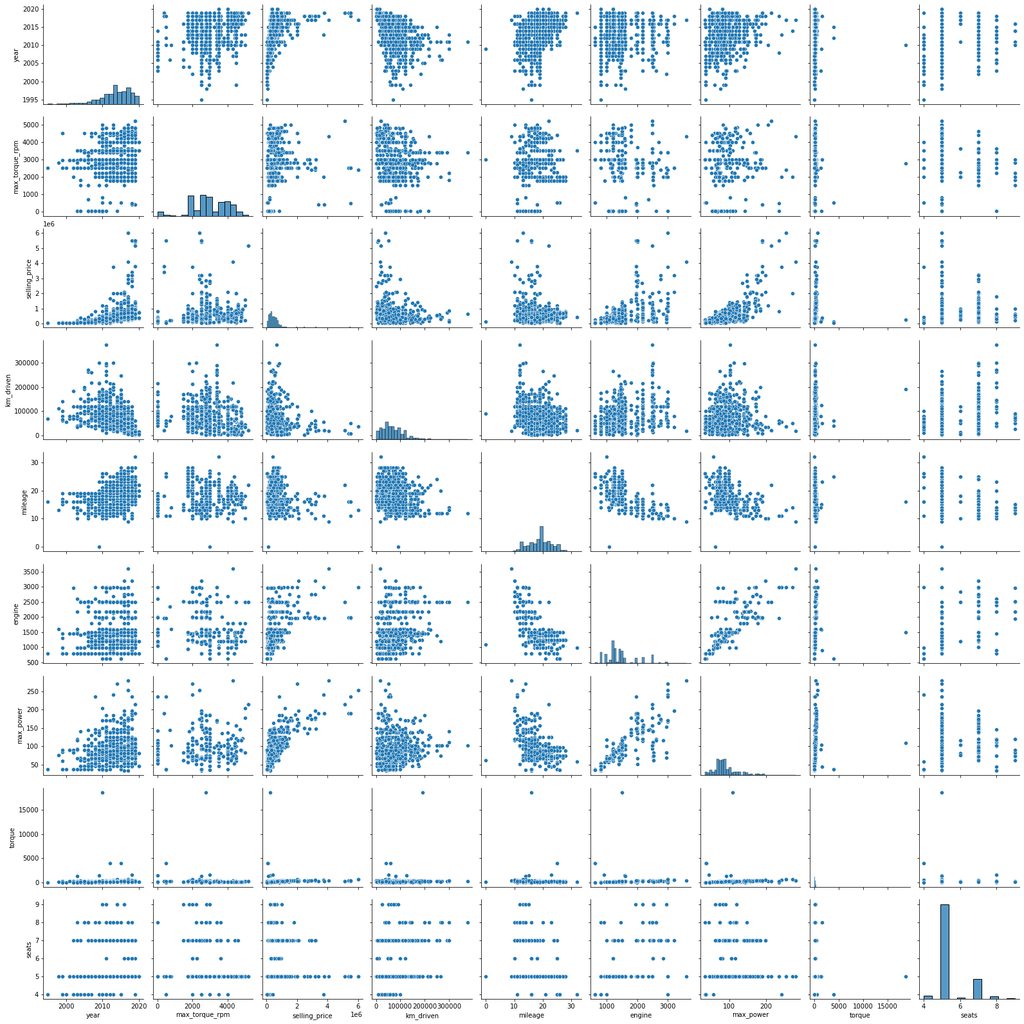

```python
sns.pairplot(df_test_feat_wnan_int)
plt.show()
```

```python
# Выведем коэффициенты корреляции для ответа на вопрос по корреляции признаков
df_test_feat_wnan_int.corr()
```

|  | year | max_torque_rpm | selling_price | km_driven | mileage | engine | max_power | torque | seats |
| --- | --- | --- | --- | --- | --- | --- | --- | --- | --- |
| year | 1.000000 | 0.228466 | 0.416422 | -0.469142 | 0.343690 | 0.000855 | 0.219236 | -0.005931 | 0.019283 |
| max_torque_rpm | 0.228466 | 1.000000 | -0.013026 | -0.248569 | -0.033283 | -0.182286 | -0.024750 | -0.080841 | -0.117457 |
| selling_price | 0.416422 | -0.013026 | 1.000000 | -0.235824 | -0.150504 | 0.464516 | 0.748937 | 0.061375 | 0.086948 |
| km_driven | -0.469142 | -0.248569 | -0.235824 | 1.000000 | -0.258031 | 0.296411 | 0.028353 | 0.090640 | 0.286780 |
| mileage | 0.343690 | -0.033283 | -0.150504 | -0.258031 | 1.000000 | -0.603515 | -0.401365 | -0.042518 | -0.476592 |
| engine | 0.000855 | -0.182286 | 0.464516 | 0.296411 | -0.603515 | 1.000000 | 0.727476 | 0.085778 | 0.632391 |
| max_power | 0.219236 | -0.024750 | 0.748937 | 0.028353 | -0.401365 | 0.727476 | 1.000000 | 0.110102 | 0.262026 |
| torque | -0.005931 | -0.080841 | 0.061375 | 0.090640 | -0.042518 | 0.085778 | 0.110102 | 1.000000 | 0.030691 |
| seats | 0.019283 | -0.117457 | 0.086948 | 0.286780 | -0.476592 | 0.632391 | 0.262026 | 0.030691 | 1.000000 |

Совокупности оказались похожими, что видно не только по графическим отображениям зависимостей, но и по выведенным значениям коэффициентов коррекляции.

(0.25 балла) Для трейна давайте построим тепловую карту (heatmap из библиотеки seaborn) попарных корреляций числовых колонок

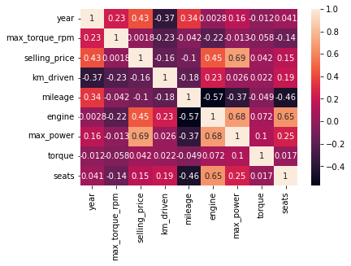

```python
sns.heatmap(df_train_feat_wnan_int.corr(), annot = True)
plt.show()
```

```python
min(df_train_feat_wnan_int.corr())
```

```
'engine'
```

Ответьте, пожалуйста, на вопросы:

- Какие 2 признака наименее скоррелированы между собой?
- Между какими наблюдается довольно сильная положительная линейная зависимость?
- Правильно ли, опираясь на данные, утверждать, что чем меньше год, тем, скорее всего, больше километров проехала машина к дате продажи.

1. Наименее скоррелированными между собой признаками по данным train являются цена продажи (selling_price) и максимальный крутящий момент (max_torque_rpm).

(0.25 балла) Отобразите диаграммe рассеяния для наиболее скореллированной пары **признаков** (на трейне)

```python
# Функция для построения диаграммы рассеивания

def scatterplot(x_data, y_data, x_label="", y_label="", title="", color = "r", yscale_log=False):

    _, ax = plt.subplots()
    ax.scatter(x_data, y_data, s = 10, color = color, alpha = 0.75)

    if yscale_log == True:
        ax.set_yscale('log')

    ax.set_title(title)
    ax.set_xlabel(x_label)
    ax.set_ylabel(y_label)
```

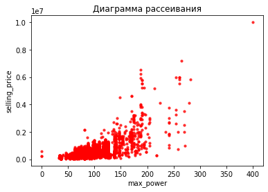

```python
# Диаграмма рассеивания между целевой переменной и признаком (для информации)

scatterplot(df_train_feat_wnan_int['max_power'], df_train_feat_wnan_int['selling_price'], 'max_power', 'selling_price', 'Диаграмма рассеивания')
plt.show()
```

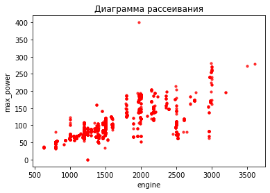

```python
# Диаграмма рассеивания только между признаками

scatterplot(df_train_feat_wnan_int['engine'], df_train_feat_wnan_int['max_power'], 'engine', 'max_power', 'Диаграмма рассеивания')
plt.show()
```

### Дополнительные визуализации (бонус 0.5 балла)

Если вам кажется, что мы не попросили вас нарисовать какие-то очень важные зависимости, нарисуйте их и поясните.

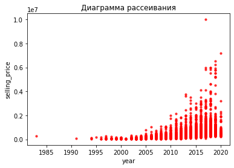

```python
scatterplot(df_train_feat_wnan_int['year'], df_train_feat_wnan_int['selling_price'], 'year', 'selling_price', 'Диаграмма рассеивания')
plt.show()
```

Считаю данную зависимость также очень важной. Она демонстрирует, то что все таки чем новее авто, тем больше будет его цена.

# Часть 2 (1.25 балла) | Модель только на вещественных признаках

(0.05 балла) В переменные ``y_train`` и ``y_test`` запишите значения целевых переменных. Столбцы ``selling_price`` из датафреймов необходимо удалить. Категориальные (все, кроме ``seats``) столбцы тоже.

```python
y_train = df_train_feat_wnan_int[['selling_price']]
columns = ['selling_price', 'name', 'fuel', 'seller_type', 'transmission', 'owner']
X_train = df_train_feat_wnan_int.drop(columns, axis = 1)
```

```python
X_train.shape
```

```
(5840, 8)
```

```python
assert X_train.shape == (5840, 8)
```

```python
y_test = df_test_feat_wnan_int[['selling_price']]
columns = ['selling_price', 'name', 'fuel', 'seller_type', 'transmission', 'owner']
X_test = df_test_feat_wnan_int.drop(columns, axis = 1)
```

```python
assert X_test.shape == (1000, 8)
```

(0.2 балла) Обучите классическую линейную регрессию с дефолтными параметрами. Посчтитайте $R^2$ и MSE для трейна и для теста

**Замечание:** $R^2$ и MSE для трейна и для теста выводите везде, где требуется обучать модели, даже если в явном виде этого не просят. Иначе непонятно, как понять, насколько успешны наши эксперименты.

```python
from sklearn.linear_model import LinearRegression
from sklearn.metrics import r2_score, mean_squared_error as MSE
```

```python
def FitPredict(model, X_train, y_train, X_test, y_test):

    model = model
    model.fit(X_train, y_train)

    pred_mse_train = pd.DataFrame(model.predict(X_train))
    pred_mse_test = pd.DataFrame(model.predict(X_test))

    print('MSE for train:', MSE(y_train, pred_mse_train))
    print('MSE for test:', MSE(y_test, pred_mse_test))

    print('r2_score for train', r2_score(y_train, pred_mse_train))
    print('r2_score for test', r2_score(y_test, pred_mse_test))

    print('Веса при признаках:', model.coef_)
    print('Свободный член:', model.intercept_)
    return model, pred_mse_train, pred_mse_test
```

```python
model, pred_mse_train, pred_mse_test = FitPredict(LinearRegression(), X_train, y_train, X_test, y_test)
```

```
MSE for train: 115566017314.75925
MSE for test: 229889989222.3174
r2_score for train 0.596822888463484
r2_score for test 0.6000720789401535
Веса при признаках: [[ 4.07635332e+04 -3.64079608e+01 -7.69900656e-01  2.33109907e+03
   7.96088008e+01  1.04394739e+04 -1.70234745e+01 -2.54106871e+04]]
Свободный член: [-82320302.41723537]
```

Запомните правило:

> Использую линейную модель -- стандартизирую фичи

(0.25 балла) Воспользуемся им

```python
from sklearn.preprocessing import StandardScaler
```

```python
scaler = StandardScaler()

X_train_SS = scaler.fit_transform(X_train)

# Берем данные о выборке для test с train выборки, как учили на семинаре
X_test_SS = scaler.transform(X_test)

X_train_SS = pd.DataFrame(data=X_train_SS)
X_test_SS = pd.DataFrame(data=X_test_SS)
```

```python
X_train_SS.head()
```

|  | 0 | 1 | 2 | 3 | 4 | 5 | 6 | 7 |
| --- | --- | --- | --- | --- | --- | --- | --- | --- |
| 0 | 0.139570 | -0.823419 | 1.191152 | 1.001523 | -0.373643 | -0.429716 | -0.031970 | -0.434419 |
| 1 | 0.139570 | -0.359270 | 0.766619 | 0.502258 | 0.141162 | 0.487641 | 0.047369 | -0.434419 |
| 2 | -0.837167 | -0.127195 | 0.883158 | 1.001523 | -0.068879 | 0.076412 | 0.007065 | -0.434419 |
| 3 | -1.569719 | -2.675837 | 0.766619 | -0.745906 | -0.270682 | 0.013146 | -0.134184 | -0.434419 |
| 4 | 0.872122 | 1.033177 | -0.482007 | 0.252625 | -0.478663 | -0.208285 | -0.132796 | -0.434419 |

```python
model, pred_mse_train, pred_mse_test = FitPredict(LinearRegression(), X_train_SS, y_train, X_test_SS, y_test)
```

```
MSE for train: 115566017314.75923
MSE for test: 229889989222.31027
r2_score for train 0.5968228884634841
r2_score for test 0.6000720789401659
Веса при признаках: [[166937.72682734 -39220.12060752 -46244.84759      9338.11535473
   38659.72542467 330018.59018166 -12874.04749138 -24959.89753678]]
Свободный член: [522960.09109589]
```

Не очень результативно.

Зато уже сейчас можем интерпретировать модель. "Какой признак оказался наиболее информативным в предсказании цены?"

Наиболее информативен признак с весовым коэффициентом в 330018.59, которым стоит при признаке мощность двигателя. Этот факт также подтверждается тем, что у признаков цена на авто и мощностью двигателя самый высокий коэффициент корреляции.

(0.25 балла) Теперь попробуем Lasso-регрессию. Здесь и дальше обучайте модели на нормализованных признаках

Занулила ли L1-регуляризация с параметрами по умолчанию какие-нибудь веса? Почему же?

```python
from sklearn.linear_model import Lasso
```

```python
model, pred_mse_train, pred_mse_test = FitPredict(Lasso(), X_train_SS, y_train, X_test_SS, y_test)
```

```
MSE for train: 115566017326.55847
MSE for test: 229890703202.03027
r2_score for train 0.5968228884223198
r2_score for test 0.6000708368659631
Веса при признаках: [166937.31526801 -39219.30165147 -46243.67606771   9336.57692363
  38655.3155754  330019.2511114  -12872.90945945 -24957.00268136]
Свободный член: [522960.09109589]
```

L1-регуляризация веса не занулила при alpha = 1 (по умолчанию). Все дело в заданном по умолчанию alpha и если его увеличивать, то веса начнут зануляться (при таком маленьком alpha модель ведет себя почти как линейная регрессия). Зануление некоторых весов это проявление свойства L1 регуляризации в части зануления тех коэффициентов, которые в меньшей мере влияют на целевую переменную, таким образом достигается более высокая точность при уменьшении весовых коэффициентов (чем больше alpha тем больше зануленных коэффициентов). Зануление весов видно при высоких значениях alpha. Например, вот зануление при alpha = 10000:

```python
model, pred_mse_train, pred_mse_test = FitPredict(Lasso(alpha = 10000), X_train_SS, y_train, X_test_SS, y_test)
```

```
MSE for train: 116527734711.2426
MSE for test: 237755214853.1516
r2_score for train 0.5934677287804042
r2_score for test 0.586389345969279
Веса при признаках: [160459.92800537 -29090.87171751 -34896.1144304       0.
   2552.58047533 334777.79253372  -1417.44085604     -0.        ]
Свободный член: [522960.09109589]
```

(0.25 балла) Перебором по сетке (c 10-ю фолдами) подберите оптимальные параметры для Lasso-регрессии

Вам пригодится класс [GridSearchCV](https://scikit-learn.org/stable/modules/generated/sklearn.model_selection.GridSearchCV.html).

```python
from sklearn.model_selection import GridSearchCV
```

```python
GridSearchCVLasso = GridSearchCV(Lasso(), param_grid = {'alpha': [i for i in range(0, 1000, 10)]}, cv = 10)
GridSearchCVLasso.fit(X_train_SS, y_train)
alpha_best = GridSearchCVLasso.best_params_

print('Оптимальное значение коэффициента регуляризации:', alpha_best['alpha'])
```

```
Оптимальное значение коэффициента регуляризации: 990
```

Сколько грид-сёрчу пришлось обучать моделей?

Какой коэффициент регуляризации у лучшей из перебранных моделей? Занулились ли какие-нибудь из весов при такой регуляризации?

```python
print('Оптимальное значение коэффициента регуляризации:', alpha_best["alpha"])
```

```
Оптимальное значение коэффициента регуляризации: 990
```

```python
model, pred_mse_train, pred_mse_test = FitPredict(Lasso(alpha = alpha_best["alpha"]), X_train_SS, y_train, X_test_SS, y_test)
```

```
MSE for train: 115577435665.18034
MSE for test: 230611371045.4259
r2_score for train 0.596783053072006
r2_score for test 0.5988171276750631
Веса при признаках: [166438.0119838  -38354.5142259  -45111.77263186   7932.07578247
  34391.03262489 330663.43373745 -11745.12852978 -22084.84216436]
Свободный член: [522960.09109589]
```

(0.25 балла) Перебором по сетке (c 10-ю фолдами) подберите оптимальные параметры для [ElasticNet](https://scikit-learn.org/stable/modules/generated/sklearn.linear_model.ElasticNet.html)-регрессии

```python
from sklearn.linear_model import ElasticNet
```

```python
GridSearchCVEN = GridSearchCV(ElasticNet(), param_grid = {'alpha': [i for i in range(0, 5000, 50)], \
                                                          'l1_ratio': [i/10 for i in range(11)]}, cv = 10)
GridSearchCVEN.fit(X_train_SS, y_train)
alpha_best, l1_ratio_best = GridSearchCVEN.best_params_
```

Какие гиперпараметры соответствуют лучшей из перебранных моделей?

```python
print('Оптимальное значение коэффициента регуляризации:', GridSearchCVEN.best_params_['alpha'])
print('Оптимальное значение l1_ratio:', GridSearchCVEN.best_params_['l1_ratio'])
```

```
Оптимальное значение коэффициента регуляризации: 4950
Оптимальное значение l1_ratio: 1.0
```

```python
model, pred_mse_train, pred_mse_test = FitPredict(ElasticNet(alpha = GridSearchCVEN.best_params_['alpha'], \
                      l1_ratio = GridSearchCVEN.best_params_['l1_ratio']),\
                      X_train_SS, y_train, X_test_SS, y_test)
```

```
MSE for train: 115851498321.41357
MSE for test: 233708989340.38843
r2_score for train 0.5958269260660957
r2_score for test 0.5934283586854605
Веса при признаках: [164610.98418175 -34974.09361887 -40541.83517621   2116.75961534
  17254.67980166 333206.35453468  -7232.67810409 -10648.71540162]
Свободный член: [522960.09109589]
```

На самом деле можно было бы перебирать больше значений гиперпараметров, но у меня даже при этих компьютер очень долго их считал. В итоге вместо ElasticNet получена обычная Lasso, так как l1_ratio = 1.0. Точность при этом осталась практически той же.

Предлагаем вам оставить вам попытки заметно улучшить качество модели регуляризацией и перейти к следующей части задания.

# Часть 3 (0.75 балла) | Добавляем категориальные фичи

(0 баллов) Из df_train удалите столбцы с целевой переменной и названием автомобиля.

```python
columns = ['name', 'selling_price']
X_train = df_train_feat_wnan_int.drop(columns, axis = 1)
X_train[['seats']] = X_train[['seats']].astype(str)
```

```python
X_train.head()
```

|  | year | max_torque_rpm | km_driven | fuel | seller_type | transmission | owner | mileage | engine | max_power | torque | seats |
| --- | --- | --- | --- | --- | --- | --- | --- | --- | --- | --- | --- | --- |
| 0 | 2014 | 2000.0 | 145500 | Diesel | Individual | Manual | First Owner | 23 | 1248.0 | 74.0 | 190.00 | 5 |
| 1 | 2014 | 2500.0 | 120000 | Diesel | Individual | Manual | Second Owner | 21 | 1498.0 | 103.0 | 250.00 | 5 |
| 2 | 2010 | 2750.0 | 127000 | Diesel | Individual | Manual | First Owner | 23 | 1396.0 | 90.0 | 219.52 | 5 |
| 3 | 2007 | 4.5 | 120000 | Petrol | Individual | Manual | First Owner | 16 | 1298.0 | 88.0 | 112.70 | 5 |
| 4 | 2017 | 4000.0 | 45000 | Petrol | Individual | Manual | First Owner | 20 | 1197.0 | 81.0 | 113.75 | 5 |

```python
assert X_train.shape == (5840, 12)
```

```python
X_train.describe(include='object')
```

|  | fuel | seller_type | transmission | owner | seats |
| --- | --- | --- | --- | --- | --- |
| count | 5840 | 5840 | 5840 | 5840 | 5840 |
| unique | 4 | 3 | 2 | 5 | 9 |
| top | Diesel | Individual | Manual | First Owner | 5 |
| freq | 3177 | 5223 | 5336 | 3603 | 4618 |

(0.5 балла) Закодируйте категориалльные фичи и ``seats`` методом OneHot-кодирования

> Обратите внимание, что во избежание мультиколлинеарности следует избавиться от одного из полученных столбцов при кодировании каждого признака методом OneHot.

```python
from sklearn.preprocessing import OneHotEncoder
```

```python
X_train_cat = X_train[['fuel', 'seller_type', 'transmission', 'owner', 'seats']]
X_train_num = X_train[['year', 'max_torque_rpm', 'km_driven', 'mileage', 'engine', 'max_power', 'torque']]
```

```python
enc = OneHotEncoder(drop = "first" , handle_unknown = 'ignore')
enc.fit(X_train_cat)
```

```
OneHotEncoder(drop='first', handle_unknown='ignore')
```

```python
X_train_cat = enc.transform(X_train_cat).toarray()
```

```python
X_train_cat = pd.DataFrame(X_train_cat)
```

```python
X_dum_train = pd.concat([X_train_num, X_train_cat], axis=1, join='inner')
```

```python
X_dum_train.head()
```

|  | year | max_torque_rpm | km_driven | mileage | engine | max_power | torque | 0 | 1 | 2 | ... | 8 | 9 | 10 | 11 | 12 | 13 | 14 | 15 | 16 | 17 |
| --- | --- | --- | --- | --- | --- | --- | --- | --- | --- | --- | --- | --- | --- | --- | --- | --- | --- | --- | --- | --- | --- |
| 0 | 2014 | 2000.0 | 145500 | 23 | 1248.0 | 74.0 | 190.00 | 1.0 | 0.0 | 0.0 | ... | 0.0 | 0.0 | 0.0 | 0.0 | 0.0 | 1.0 | 0.0 | 0.0 | 0.0 | 0.0 |
| 1 | 2014 | 2500.0 | 120000 | 21 | 1498.0 | 103.0 | 250.00 | 1.0 | 0.0 | 0.0 | ... | 0.0 | 0.0 | 0.0 | 0.0 | 0.0 | 1.0 | 0.0 | 0.0 | 0.0 | 0.0 |
| 2 | 2010 | 2750.0 | 127000 | 23 | 1396.0 | 90.0 | 219.52 | 1.0 | 0.0 | 0.0 | ... | 0.0 | 0.0 | 0.0 | 0.0 | 0.0 | 1.0 | 0.0 | 0.0 | 0.0 | 0.0 |
| 3 | 2007 | 4.5 | 120000 | 16 | 1298.0 | 88.0 | 112.70 | 0.0 | 0.0 | 1.0 | ... | 0.0 | 0.0 | 0.0 | 0.0 | 0.0 | 1.0 | 0.0 | 0.0 | 0.0 | 0.0 |
| 4 | 2017 | 4000.0 | 45000 | 20 | 1197.0 | 81.0 | 113.75 | 0.0 | 0.0 | 1.0 | ... | 0.0 | 0.0 | 0.0 | 0.0 | 0.0 | 1.0 | 0.0 | 0.0 | 0.0 | 0.0 |

5 rows × 25 columns

```python
# Аналогичные действия проделаем для test
columns = ['name', 'selling_price']
X_test = df_test_feat_wnan_int.drop(columns, axis = 1)
X_test[['seats']] = X_test[['seats']].astype(str)
X_test_cat = X_test[['fuel', 'seller_type', 'transmission', 'owner', 'seats']]
X_test_num = X_test[['year', 'max_torque_rpm', 'km_driven', 'mileage', 'engine', 'max_power', 'torque']]
X_test_cat = enc.transform(X_test_cat).toarray()
X_test_cat = pd.DataFrame(X_test_cat)
X_dum_test = pd.concat([X_test_num, X_test_cat], axis=1, join='inner')
X_dum_test.head()
```

|  | year | max_torque_rpm | km_driven | mileage | engine | max_power | torque | 0 | 1 | 2 | ... | 8 | 9 | 10 | 11 | 12 | 13 | 14 | 15 | 16 | 17 |
| --- | --- | --- | --- | --- | --- | --- | --- | --- | --- | --- | --- | --- | --- | --- | --- | --- | --- | --- | --- | --- | --- |
| 0 | 2010 | 2200.0 | 168000 | 14 | 2498.0 | 112.0 | 260.0 | 1.0 | 0.0 | 0.0 | ... | 0.0 | 0.0 | 0.0 | 0.0 | 0.0 | 0.0 | 0.0 | 1.0 | 0.0 | 0.0 |
| 1 | 2017 | 2750.0 | 25000 | 21 | 1497.0 | 108.0 | 260.0 | 1.0 | 0.0 | 0.0 | ... | 0.0 | 0.0 | 0.0 | 0.0 | 0.0 | 1.0 | 0.0 | 0.0 | 0.0 | 0.0 |
| 2 | 2007 | 4300.0 | 218463 | 12 | 1799.0 | 130.0 | 172.0 | 0.0 | 0.0 | 1.0 | ... | 0.0 | 0.0 | 0.0 | 0.0 | 0.0 | 1.0 | 0.0 | 0.0 | 0.0 | 0.0 |
| 3 | 2015 | 1750.0 | 173000 | 25 | 1498.0 | 98.0 | 200.0 | 1.0 | 0.0 | 0.0 | ... | 0.0 | 0.0 | 0.0 | 0.0 | 0.0 | 1.0 | 0.0 | 0.0 | 0.0 | 0.0 |
| 4 | 2011 | 3000.0 | 70000 | 16 | 1172.0 | 65.0 | 96.0 | 0.0 | 0.0 | 1.0 | ... | 0.0 | 0.0 | 0.0 | 0.0 | 0.0 | 1.0 | 0.0 | 0.0 | 0.0 | 0.0 |

5 rows × 25 columns

Тут представлен второй способ кодирования категориальных признаков, но чтобы на тесте в данном случае подсчитать предикты и для других данных при применении pd.get_dummies вознмикает очень много сложностей и проблем. Могут быть категории не такие как в train. Точность была 0,67 с этим кодированием.

```python
# X_dum = pd.get_dummies(X_train_cat, drop_first=True)
# X_dum.head()
```

```python
# X_dum = scaler.fit_transform(X_dum)
# X_dum = pd.DataFrame(data=X_dum)
# X_dum.head()
```

```python
scaler = StandardScaler()

X_dum_train_SS = scaler.fit_transform(X_dum_train)

# Берем данные о выборке для test с train выборки, как учили на семинаре
X_dum_test_SS = scaler.transform(X_dum_test)

X_dum_train_SS = pd.DataFrame(data=X_dum_train_SS)
X_dum_test_SS = pd.DataFrame(data=X_dum_test_SS)
```

(0.25 балла) Переберите параметр регуляризации `alpha` для гребневой (ridge) регрессии с помощью класса `GridSearchCV`. В качестве параметров при объявлении GridSearchCV кроме модели укажите метрику качества $R^2$. Кроссвалидируйтесь по 10-ти фолдам.

Удалось ли улучшить качество предсказаний?

```python
from sklearn.linear_model import Ridge
from sklearn.model_selection import GridSearchCV
```

```python
GridSearchRidge = GridSearchCV(Ridge(), param_grid = {'alpha': [i for i in range(0, 800, 5)]}, scoring = 'r2',cv = 10)
GridSearchRidge.fit(X_dum_train_SS, y_train)
```

```
GridSearchCV(cv=10, estimator=Ridge(),
             param_grid={'alpha': [0, 5, 10, 15, 20, 25, 30, 35, 40, 45, 50, 55,
                                   60, 65, 70, 75, 80, 85, 90, 95, 100, 105,
                                   110, 115, 120, 125, 130, 135, 140, 145, ...]},
             scoring='r2')
```

```python
GridSearchRidge.best_params_
```

```
{'alpha': 565}
```

```python
model, pred_mse_train, pred_mse_test = FitPredict(Ridge(alpha = GridSearchRidge.best_params_['alpha']), X_dum_train_SS, y_train, X_dum_test_SS, y_test)
```

```
MSE for train: 95841481362.31015
MSE for test: 220567773981.15762
r2_score for train 0.6656362093383131
r2_score for test 0.6162894626273745
Веса при признаках: [[ 1.42050168e+05 -2.09100153e+04 -3.40000502e+04  2.13394897e+04
   5.56104304e+04  2.44556053e+05 -1.05601907e+04  1.25862738e+04
   8.64380090e+03 -1.18211509e+04 -3.39028182e+04 -6.64172191e+03
  -8.57731932e+04 -8.56494345e+03 -2.75049722e+04  8.06988765e+04
  -1.40774066e+04 -2.68157273e+03  5.68947991e+02  5.92596875e+04
  -7.15996966e+03 -9.36693780e+03 -4.56666379e+03  1.54634353e+02
  -4.92292914e+03]]
Свободный член: [522960.09109589]
```

Качество предсказаний удалось увеличить для train и test.

Второй вариант реализации через get_dummies

```python
# model = Ridge(alpha = GridSearchRidge.best_params_['alpha'])
# model.fit(X_dum_train, y_train)

# pred_mse_train = model.predict(X_dum_train)

# print('MSE for train:', MSE(y_train, pred_mse_train))
# print('r2_score for train', r2_score(y_train, pred_mse_train))
# print('Веса при признаках:', model.coef_)
# print('Свободный член:', model.intercept_)
```

# Часть 4 - бонусная (2 балла) | Feature Engineering

В этой части домашнего задания вам предлагается проявить свою креативность для улучшения прогноза модели. Любые другие модели, кроме различных форм линейной (или полиномиальной) регресси, использовать запрещается. А значит, придется работать с признаками

**Что можно попробовать сделать?** (каждый пункт по 0.4 балла, но не больше 2-х баллов в сумме)

1. *Сгенерировать новые признаки на основе уже существующих:*
   - посчитать произведения // частные признаков (кажется, что посчитать число "лошадей" на литр объема может быть полезно);
   - имеет смысл обратить внимание на визуализации в части с EDA (к примеру, зависимость цены от года выглядит квадратичной, а не линейной; значит, квадрат года нам, скорее всего, принесет больше пользы)
2. *Добыть новые признаки:*
   - имеем название автомобиля, которое никак не используем (можно спарсить инфу о классе автомобиля или каких-то специфических опциях)
   - можно добавить пороговые признаки вроде "владелец третий или больше" и объединить признаки в некоторые осмысленные правила, например "первый или второй владелец и продавец официальный дилер" (подбирать пороги удобно по диаграммам рассеяния)
3. *Поработать с уже имеющимися:*
   - далеко не факт, что заполнить пропуск медианой было лучшей идеей (как минимум, можно добавить dummy-столбец для модели, сигнализирующий, что раньше на месте медианы был пропуск -- там где он был, конечно); попробуйте другие способы филлинга;
   - мы не анализировали, есть ли в данных выбросы => никак выбросы не обрабатывали; наиболее простым и, тем не менее, довольно полезным вариантом нахождения выбросов могут послужить boxplot'ы для каждого столбца; что делать с выбросами думайте сами :) -- вариантов довольно много
   - мы толком не смотрели на таргет сам по себе; в нем тоже могут быть неожиданности -- стоит хотя бы проверить
   - можно заметить, что некоторые признаки распределены совсем не нормально; возможно их стоит отлогарифмировать

И так далее...

Feel Free to Try!

```python
df_train_feat_wnan_int_1 = df_train_feat_wnan_int.copy()

df_train_feat_wnan_int_1.insert(2, 'max_power_engine', [np.nan for i in range(len(df_train_feat_wnan_int))], True)
df_train_feat_wnan_int_1.insert(2, 'yearsq', [(df_train_feat_wnan_int_1['year'][i])**2  for i in range(len(df_train_feat_wnan_int))], True)

for i in tqdm(range(len(df_train_feat_wnan_int_1))):
    df_train_feat_wnan_int_1['max_power_engine'][i] = df_train_feat_wnan_int_1['max_power'][i] / \
    df_train_feat_wnan_int_1['engine'][i]
```

```python
df_train_feat_wnan_int_1.head()
```

|  | name | year | yearsq | max_power_engine | max_torque_rpm | selling_price | km_driven | fuel | seller_type | transmission | owner | mileage | engine | max_power | torque | seats |
| --- | --- | --- | --- | --- | --- | --- | --- | --- | --- | --- | --- | --- | --- | --- | --- | --- |
| 0 | Maruti Swift Dzire VDI | 2014 | 4056196 | 0.059295 | 2000.0 | 450000 | 145500 | Diesel | Individual | Manual | First Owner | 23 | 1248.0 | 74.0 | 190.00 | 5 |
| 1 | Skoda Rapid 1.5 TDI Ambition | 2014 | 4056196 | 0.068758 | 2500.0 | 370000 | 120000 | Diesel | Individual | Manual | Second Owner | 21 | 1498.0 | 103.0 | 250.00 | 5 |
| 2 | Hyundai i20 Sportz Diesel | 2010 | 4040100 | 0.064470 | 2750.0 | 225000 | 127000 | Diesel | Individual | Manual | First Owner | 23 | 1396.0 | 90.0 | 219.52 | 5 |
| 3 | Maruti Swift VXI BSIII | 2007 | 4028049 | 0.067797 | 4.5 | 130000 | 120000 | Petrol | Individual | Manual | First Owner | 16 | 1298.0 | 88.0 | 112.70 | 5 |
| 4 | Hyundai Xcent 1.2 VTVT E Plus | 2017 | 4068289 | 0.067669 | 4000.0 | 440000 | 45000 | Petrol | Individual | Manual | First Owner | 20 | 1197.0 | 81.0 | 113.75 | 5 |

```python
df_test_feat_wnan_int_1 = df_test_feat_wnan_int.copy()

df_test_feat_wnan_int_1.insert(2, 'max_power_engine', [np.nan for i in range(len(df_test_feat_wnan_int))], True)
df_test_feat_wnan_int_1.insert(2, 'yearsq', [(df_test_feat_wnan_int_1['year'][i])**2  for i in range(len(df_test_feat_wnan_int))], True)

for i in tqdm(range(len(df_test_feat_wnan_int_1))):
    df_test_feat_wnan_int_1['max_power_engine'][i] = df_test_feat_wnan_int_1['max_power'][i] / \
    df_test_feat_wnan_int_1['engine'][i]
```

```python
df_test_feat_wnan_int_1.head()
```

|  | name | year | yearsq | max_power_engine | max_torque_rpm | selling_price | km_driven | fuel | seller_type | transmission | owner | mileage | engine | max_power | torque | seats |
| --- | --- | --- | --- | --- | --- | --- | --- | --- | --- | --- | --- | --- | --- | --- | --- | --- |
| 0 | Mahindra Xylo E4 BS IV | 2010 | 4040100 | 0.044836 | 2200.0 | 229999 | 168000 | Diesel | Individual | Manual | First Owner | 14 | 2498.0 | 112.0 | 260.0 | 7 |
| 1 | Tata Nexon 1.5 Revotorq XE | 2017 | 4068289 | 0.072144 | 2750.0 | 665000 | 25000 | Diesel | Individual | Manual | First Owner | 21 | 1497.0 | 108.0 | 260.0 | 5 |
| 2 | Honda Civic 1.8 S AT | 2007 | 4028049 | 0.072262 | 4300.0 | 175000 | 218463 | Petrol | Individual | Automatic | First Owner | 12 | 1799.0 | 130.0 | 172.0 | 5 |
| 3 | Honda City i DTEC VX | 2015 | 4060225 | 0.065421 | 1750.0 | 635000 | 173000 | Diesel | Individual | Manual | First Owner | 25 | 1498.0 | 98.0 | 200.0 | 5 |
| 4 | Tata Indica Vista Aura 1.2 Safire BSIV | 2011 | 4044121 | 0.055461 | 3000.0 | 130000 | 70000 | Petrol | Individual | Manual | Second Owner | 16 | 1172.0 | 65.0 | 96.0 | 5 |

```python
# Проделаем все тоже что и прошлом разделе (не буду повторно комментировать)

columns = ['name', 'selling_price']
X_train = df_train_feat_wnan_int_1.drop(columns, axis = 1)
X_train[['seats']] = X_train[['seats']].astype(str)

X_train_cat = X_train[['fuel', 'seller_type', 'transmission', 'owner', 'seats']]
X_train_num = X_train[['year', 'yearsq', 'max_torque_rpm', 'km_driven', 'mileage', 'engine', 'max_power', 'torque', 'max_power_engine']]

enc = OneHotEncoder(drop = "first" , handle_unknown = 'ignore')
enc.fit(X_train_cat)

X_train_cat = enc.transform(X_train_cat).toarray()

X_train_cat = pd.DataFrame(X_train_cat)

X_dum_train = pd.concat([X_train_num, X_train_cat], axis=1, join='inner')

columns = ['name', 'selling_price']
X_test = df_test_feat_wnan_int_1.drop(columns, axis = 1)
X_test[['seats']] = X_test[['seats']].astype(str)
X_test_cat = X_test[['fuel', 'seller_type', 'transmission', 'owner', 'seats']]
X_test_num = X_test[['year', 'yearsq', 'max_torque_rpm', 'km_driven', 'mileage', 'engine', 'max_power', 'torque', 'max_power_engine']]
X_test_cat = enc.transform(X_test_cat).toarray()
X_test_cat = pd.DataFrame(X_test_cat)
X_dum_test = pd.concat([X_test_num, X_test_cat], axis=1, join='inner')

scaler = StandardScaler()

X_dum_train_SS = scaler.fit_transform(X_dum_train)

X_dum_test_SS = scaler.transform(X_dum_test)

X_dum_train_SS = pd.DataFrame(data=X_dum_train_SS)
X_dum_test_SS = pd.DataFrame(data=X_dum_test_SS)
```

```python
GridSearchRidge = GridSearchCV(Ridge(), param_grid = {'alpha': [i for i in range(0, 800, 5)]}, scoring = 'r2',cv = 10)
GridSearchRidge.fit(X_dum_train_SS, y_train)
```

```
GridSearchCV(cv=10, estimator=Ridge(),
             param_grid={'alpha': [0, 5, 10, 15, 20, 25, 30, 35, 40, 45, 50, 55,
                                   60, 65, 70, 75, 80, 85, 90, 95, 100, 105,
                                   110, 115, 120, 125, 130, 135, 140, 145, ...]},
             scoring='r2')
```

```python
model, pred_mse_train, pred_mse_test = FitPredict(Ridge(alpha = GridSearchRidge.best_params_['alpha']), X_dum_train_SS, y_train, X_dum_test_SS, y_test)
```

```
MSE for train: 93668958967.30847
MSE for test: 209348793419.8122
r2_score for train 0.6732155248180489
r2_score for test 0.6358065524645085
Веса при признаках: [[ 69529.08983048  92558.92251779 -28982.31323682 -29440.83259308
   32486.14659804 -52078.81519077 394377.43483136 -12677.57191153
  -88788.23959196  10986.89737864  12314.19778434   7366.94334816
  -31817.82252327  -6855.13777413 -78169.81367554  -6033.07372339
  -24724.8165745   86336.30896874 -10788.111538    -2586.20514159
    2282.41992393  60109.6548107  -17591.28287624 -12821.32541285
  -12582.93293596    539.88609206   -671.11954962]]
Свободный член: [522960.09109589]
```

Удалось еще повысить больше точность модели. Это лучшая моя модель. Сохраним ее в pickle для использования на веб-сервисе.

```python
import pickle
```

```python
tuple_objects = (model, MSE(y_test, pred_mse_test), r2_score(y_test, pred_mse_test), model.coef_, \
                 model.intercept_, enc, scaler)

pickle.dump(tuple_objects, open("tuple_model_best.pkl", 'wb'))
```

```python
# Проверим, что сохранено в .pickle
model, MSE, r2_score, coef, \
                 intercept, enc, scaler = pickle.load(open("tuple_model_best.pkl", 'rb'))
```

```python
model
```

```
Ridge(alpha=25)
```

```python
MSE
```

```
209348793419.8122
```

```python
r2_score
```

```
0.6358065524645085
```

```python
coef
```

```
array([[ 69529.08983048,  92558.92251779, -28982.31323682,
        -29440.83259308,  32486.14659804, -52078.81519077,
        394377.43483136, -12677.57191153, -88788.23959196,
         10986.89737864,  12314.19778434,   7366.94334816,
        -31817.82252327,  -6855.13777413, -78169.81367554,
         -6033.07372339, -24724.8165745 ,  86336.30896874,
        -10788.111538  ,  -2586.20514159,   2282.41992393,
         60109.6548107 , -17591.28287624, -12821.32541285,
        -12582.93293596,    539.88609206,   -671.11954962]])
```

```python
intercept
```

```
array([522960.09109589])
```

```python
enc
```

```
OneHotEncoder(drop='first', handle_unknown='ignore')
```

```python
scaler
```

```
StandardScaler()
```